[figure not shown]

Autonomous_Vehicles_SVHN_single Project

# Context

Part A: A communications equipment manufacturing company wants to build a machine learning model to predict the signal quality of their product, which emits informative signals, using various parameters.

Part B: Recognizing multi-digit numbers in photographs captured at street level is crucial for modern map making. Google's Street View imagery is a prime example. This project focuses on building a digit classifier on the SVHN (Street View Housing Number) dataset, using images centered around a single digit, which is more complex than MNIST due to distractors.

# Objective

Part A: To build a classifier that can use given parameters to determine the signal strength or quality.

Part B: To build a digit classifier on the SVHN (Street View Housing Number) dataset.

# Data Description

Part A:

- **Parameters:** Various measurable signal parameters.
- **Signal_Quality:** Final signal strength or quality.

Part B:

- **SVHN Dataset:** A real-world image dataset obtained from house numbers in Google Street View images.
- **Images:** Images centered around a single digit, with some distractors.
- **Labels:** The prominent number in each image (e.g., 2, 6, 7, 4).
- **Format:** Dataset provided in h5py files.

## Part A - Q1 A - Read the ‘Signals.csv’ as DatFrame and import required libraries.

```python
#%tensorflow_version 2.x
import tensorflow as tf
tf.__version__
```

```
'2.18.0'
```

```python
# Install the SciKeras wrapper for integrating Keras models with scikit-learn
!pip install scikeras
```

```python
# Importing essential libraries for data manipulation and visualization
import numpy as np  # Numerical computations
import pandas as pd  # Data manipulation
import seaborn as sns  # Data visualization
import scipy.stats as stats  # Statistical functions
import matplotlib.pyplot as plt  # Plotting
import h5py  # Handling HDF5 files
import warnings
warnings.filterwarnings("ignore", category=UserWarning)
from scipy.stats import zscore  # Z-score normalization

from sklearn.metrics import confusion_matrix, classification_report  # Performance evaluation
from tensorflow import keras  # Neural networks
from sklearn.model_selection import train_test_split  # Data splitting
from sklearn.preprocessing import StandardScaler  # Feature scaling
from tensorflow.keras.utils import to_categorical  # One-hot encoding
from tensorflow.keras.models import Sequential, load_model  # Neural network models
from tensorflow.keras.layers import Flatten, Dense  # Neural network layers
from tensorflow.keras import regularizers, optimizers  # Regularization and optimization
from sklearn.metrics import r2_score  # Regression metrics
from tensorflow.keras.layers import Dense, Input, Dropout, BatchNormalization  # Additional layers
from scikeras.wrappers import KerasClassifier  # Wrapper for using Keras with scikit-learn
from tensorflow.keras import losses  # Loss functions
from tensorflow.keras import optimizers  # Optimizers
from tensorflow.keras import layers
```

```python
# Initialize the random number generator
import random
seed = 7
np.random.seed(seed)

# Ignore the warnings
import warnings
warnings.filterwarnings("ignore")
```

# PART-A

## Data Overview

```python
#Read the data as a data frame
df = pd.read_csv('/content/NN Project Data - Signal.csv')
df.head(10)
```

|  | Parameter 1 | Parameter 2 | Parameter 3 | Parameter 4 | Parameter 5 | Parameter 6 | Parameter 7 | Parameter 8 | Parameter 9 | Parameter 10 | Parameter 11 | Signal_Strength |
| --- | --- | --- | --- | --- | --- | --- | --- | --- | --- | --- | --- | --- |
| 0 | 7.4 | 0.70 | 0.00 | 1.9 | 0.076 | 11.0 | 34.0 | 0.9978 | 3.51 | 0.56 | 9.4 | 5 |
| 1 | 7.8 | 0.88 | 0.00 | 2.6 | 0.098 | 25.0 | 67.0 | 0.9968 | 3.20 | 0.68 | 9.8 | 5 |
| 2 | 7.8 | 0.76 | 0.04 | 2.3 | 0.092 | 15.0 | 54.0 | 0.9970 | 3.26 | 0.65 | 9.8 | 5 |
| 3 | 11.2 | 0.28 | 0.56 | 1.9 | 0.075 | 17.0 | 60.0 | 0.9980 | 3.16 | 0.58 | 9.8 | 6 |
| 4 | 7.4 | 0.70 | 0.00 | 1.9 | 0.076 | 11.0 | 34.0 | 0.9978 | 3.51 | 0.56 | 9.4 | 5 |
| 5 | 7.4 | 0.66 | 0.00 | 1.8 | 0.075 | 13.0 | 40.0 | 0.9978 | 3.51 | 0.56 | 9.4 | 5 |
| 6 | 7.9 | 0.60 | 0.06 | 1.6 | 0.069 | 15.0 | 59.0 | 0.9964 | 3.30 | 0.46 | 9.4 | 5 |
| 7 | 7.3 | 0.65 | 0.00 | 1.2 | 0.065 | 15.0 | 21.0 | 0.9946 | 3.39 | 0.47 | 10.0 | 7 |
| 8 | 7.8 | 0.58 | 0.02 | 2.0 | 0.073 | 9.0 | 18.0 | 0.9968 | 3.36 | 0.57 | 9.5 | 7 |
| 9 | 7.5 | 0.50 | 0.36 | 6.1 | 0.071 | 17.0 | 102.0 | 0.9978 | 3.35 | 0.80 | 10.5 | 5 |

## Part A - Q1 B - Check for missing values and print percentage for each attribute.

```python
# Checking the presence of missing values
null_counts = df.isnull().sum()  # This prints the columns with the number of null values they have
print (null_counts)
```

```
Parameter 1        0
Parameter 2        0
Parameter 3        0
Parameter 4        0
Parameter 5        0
Parameter 6        0
Parameter 7        0
Parameter 8        0
Parameter 9        0
Parameter 10       0
Parameter 11       0
Signal_Strength    0
dtype: int64
```

```python
df.isnull().sum() * 100 / len(df)  # Check and calculate percentage of missing values
```

|  | 0 |
| --- | --- |
| Parameter 1 | 0.0 |
| Parameter 2 | 0.0 |
| Parameter 3 | 0.0 |
| Parameter 4 | 0.0 |
| Parameter 5 | 0.0 |
| Parameter 6 | 0.0 |
| Parameter 7 | 0.0 |
| Parameter 8 | 0.0 |
| Parameter 9 | 0.0 |
| Parameter 10 | 0.0 |
| Parameter 11 | 0.0 |
| Signal_Strength | 0.0 |

**dtype:** float64

## Part A - Q1 C - Check for presence of duplicate records in the dataset and impute with appropriate method.

```python
# checking for duplicate values
df.duplicated().value_counts()
```

|  | count |
| --- | --- |
| False | 1359 |
| True | 240 |

**dtype:** int64

- There are 1359 rows in the DataFrame that are not duplicates (False).
- There are 240 rows in the DataFrame that are duplicates (True).

```python
df = df.drop_duplicates(keep='first')  # Remove duplicates
```

- Since your dataset had exact duplicates, the best approach is to remove them while keeping the first occurrence.

```python
df.duplicated ()
```

|  | 0 |
| --- | --- |
| 0 | False |
| 1 | False |
| 2 | False |
| 3 | False |
| 5 | False |
| ... | ... |
| 1593 | False |
| 1594 | False |
| 1595 | False |
| 1597 | False |
| 1598 | False |

1359 rows × 1 columns

**dtype:** bool

- Since no duplicates were found, no further action regarding duplicate removal is necessary.

## Part A - Q1 D - Visualise distribution of the target variable.

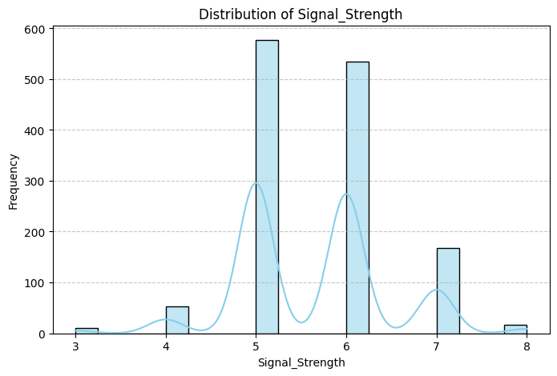

```python
# Identify the target variable (assumed as the last column)
target_column = df.columns[-1]

# Plot the distribution of the target variable
plt.figure(figsize=(8, 5))
sns.histplot(df[target_column], kde=True, bins=20, color='skyblue')
plt.xlabel(target_column)
plt.ylabel("Frequency")
plt.title(f"Distribution of {target_column}")
plt.grid(axis="y", linestyle="--", alpha=0.7)
plt.show()
```

### Observations:

- **Shape of Distribution:** The histogram suggests that the target variable has a somewhat skewed distribution, indicating an uneven spread of values.
- **Peak Frequency:** There are specific values where the frequency is significantly higher, suggesting that certain signal strengths occur more frequently in the dataset.
- **Potential Outliers:** If there are extreme values on either end, they might indicate outliers that need further investigation.
- **Spread of Values:** The range of values can help determine whether normalization or transformation techniques (e.g., log transformation) are needed for model performance improvements.
- **KDE Curve Insight:** The KDE curve helps visualize the density of data points, showing where most values are concentrated.

## Part A - Q1 E - Share insights from the initial data analysis (at least 2).

### Insights from Initial Data Analysis:

- **Presence of Duplicates:** The dataset initially contained duplicate records, which were removed to ensure data integrity.
- **Target Variable Distribution:** The distribution of the target variable is skewed, indicating the need for potential transformation techniques to improve model performance.

## Part A - Q2 A - Split the data into X & Y.

```python
X = df.drop("Signal_Strength", axis=1)
y = df['Signal_Strength']
```

## Part A - Q2 B - Split the data into train & test with 70:30 proportion.

```python
# splitting to create test data
X_vtrain, X_test, y_vtrain, y_test = train_test_split(X, y, test_size=.30, random_state=seed)
```

## Part A - Q2 C - Print shape of all the 4 variables and verify if train and test data is in sync.

```python
print("Shapes of the split datasets:")
print(f"X_vtrain shape: {X_vtrain.shape}")
print(f"X_test shape: {X_test.shape}")
print(f"y_vtrain shape: {y_vtrain.shape}")
print(f"y_test shape: {y_test.shape}")
```

```
Shapes of the split datasets:
X_vtrain shape: (951, 11)
X_test shape: (408, 11)
y_vtrain shape: (951,)
y_test shape: (408,)
```

## **Observation**

- The training dataset contains **951 samples** with **11 features**.
- The test dataset consists of **408 samples** with the same **11 features**.

```python
# splitting to create training and validation data
X_train, X_val, y_train, y_val = train_test_split(X_vtrain, y_vtrain, test_size=.20, random_state=seed)
```

## Part A - Q2 D - Normalise the train and test data with appropriate method.

```python
# Standardize the feature data to improve model performance
scaler = StandardScaler()
X_vtrain_scaled = scaler.fit_transform(X_vtrain)
X_test_scaled = scaler.transform(X_test)
```

## Part A - Q2 E - Transform Labels into format acceptable by Neural Network

```python
# Encode categorical target variables into numerical values
from sklearn.preprocessing import LabelEncoder
label_encoder = LabelEncoder()
y_vtrain_encoded = label_encoder.fit_transform(y_vtrain)  # Fit and transform training labels
y_test_encoded = label_encoder.transform(y_test)  # Transform test labels using the same encoder
```

## Part A - Q3 A - Design a Neural Network to train a classifier.

```python
from tensorflow.keras import layers

# Define the neural network model
model = keras.Sequential([
    layers.Dense(1024, activation='relu', input_shape=(X_vtrain_scaled.shape[1],)),  # Input layer
    layers.BatchNormalization(),  # Normalize activations
    layers.Dropout(0.3),  # Reduce overfitting
    layers.Dense(512, activation='relu'),
    layers.BatchNormalization(),
    layers.Dropout(0.3),
    layers.Dense(256, activation='relu'),
    layers.BatchNormalization(),
    layers.Dropout(0.3),
    layers.Dense(len(set(y_vtrain_encoded)), activation='softmax')  # Output layer with softmax for classification
])

# Compile the model with Adam optimizer and sparse categorical cross-entropy loss
model.compile(optimizer=keras.optimizers.Adam(learning_rate=0.0001),
              loss='sparse_categorical_crossentropy',
              metrics=['accuracy'])

# Display model architecture
model.summary()
```

```
Model: "sequential_2"
```

```
┏━━━━━━━━━━━━━━━━━━━━━━━━━━━━━━━━━━━━━━┳━━━━━━━━━━━━━━━━━━━━━━━━━━━━━┳━━━━━━━━━━━━━━━━━┓
┃ Layer (type)                         ┃ Output Shape                ┃         Param # ┃
┡━━━━━━━━━━━━━━━━━━━━━━━━━━━━━━━━━━━━━━╇━━━━━━━━━━━━━━━━━━━━━━━━━━━━━╇━━━━━━━━━━━━━━━━━┩
│ dense_8 (Dense)                      │ (None, 1024)                │          12,288 │
├──────────────────────────────────────┼─────────────────────────────┼─────────────────┤
│ batch_normalization_6                │ (None, 1024)                │           4,096 │
│ (BatchNormalization)                 │                             │                 │
├──────────────────────────────────────┼─────────────────────────────┼─────────────────┤
│ dropout_6 (Dropout)                  │ (None, 1024)                │               0 │
├──────────────────────────────────────┼─────────────────────────────┼─────────────────┤
│ dense_9 (Dense)                      │ (None, 512)                 │         524,800 │
├──────────────────────────────────────┼─────────────────────────────┼─────────────────┤
│ batch_normalization_7                │ (None, 512)                 │           2,048 │
│ (BatchNormalization)                 │                             │                 │
├──────────────────────────────────────┼─────────────────────────────┼─────────────────┤
│ dropout_7 (Dropout)                  │ (None, 512)                 │               0 │
├──────────────────────────────────────┼─────────────────────────────┼─────────────────┤
│ dense_10 (Dense)                     │ (None, 256)                 │         131,328 │
├──────────────────────────────────────┼─────────────────────────────┼─────────────────┤
│ batch_normalization_8                │ (None, 256)                 │           1,024 │
│ (BatchNormalization)                 │                             │                 │
├──────────────────────────────────────┼─────────────────────────────┼─────────────────┤
│ dropout_8 (Dropout)                  │ (None, 256)                 │               0 │
├──────────────────────────────────────┼─────────────────────────────┼─────────────────┤
│ dense_11 (Dense)                     │ (None, 6)                   │           1,542 │
└──────────────────────────────────────┴─────────────────────────────┴─────────────────┘
```

```
 Total params: 677,126 (2.58 MB)
```

```
 Trainable params: 673,542 (2.57 MB)
```

```
 Non-trainable params: 3,584 (14.00 KB)
```

## Part A - Q3 B - Train the classifier using previously designed Architecture

```
8/8 ━━━━━━━━━━━━━━━━━━━━ 5s 76ms/step - accuracy: 0.1945 - loss: 2.4953 - val_accuracy: 0.3284 - val_loss: 1.7694
8/8 ━━━━━━━━━━━━━━━━━━━━ 0s 38ms/step - accuracy: 0.3074 - loss: 2.0184 - val_accuracy: 0.4216 - val_loss: 1.7269
8/8 ━━━━━━━━━━━━━━━━━━━━ 1s 34ms/step - accuracy: 0.3518 - loss: 2.0200 - val_accuracy: 0.4559 - val_loss: 1.6987
8/8 ━━━━━━━━━━━━━━━━━━━━ 0s 37ms/step - accuracy: 0.3530 - loss: 1.9462 - val_accuracy: 0.4853 - val_loss: 1.6753
8/8 ━━━━━━━━━━━━━━━━━━━━ 0s 38ms/step - accuracy: 0.3932 - loss: 1.8495 - val_accuracy: 0.5025 - val_loss: 1.6526
8/8 ━━━━━━━━━━━━━━━━━━━━ 0s 40ms/step - accuracy: 0.4377 - loss: 1.7484 - val_accuracy: 0.5074 - val_loss: 1.6313
8/8 ━━━━━━━━━━━━━━━━━━━━ 0s 34ms/step - accuracy: 0.4400 - loss: 1.7891 - val_accuracy: 0.4926 - val_loss: 1.6121
8/8 ━━━━━━━━━━━━━━━━━━━━ 0s 36ms/step - accuracy: 0.4671 - loss: 1.6553 - val_accuracy: 0.5172 - val_loss: 1.5832
8/8 ━━━━━━━━━━━━━━━━━━━━ 0s 37ms/step - accuracy: 0.4931 - loss: 1.6520 - val_accuracy: 0.5245 - val_loss: 1.5531
8/8 ━━━━━━━━━━━━━━━━━━━━ 0s 35ms/step - accuracy: 0.4726 - loss: 1.6948 - val_accuracy: 0.5270 - val_loss: 1.5216
8/8 ━━━━━━━━━━━━━━━━━━━━ 0s 39ms/step - accuracy: 0.4649 - loss: 1.5765 - val_accuracy: 0.5319 - val_loss: 1.4978
8/8 ━━━━━━━━━━━━━━━━━━━━ 0s 36ms/step - accuracy: 0.5040 - loss: 1.6409 - val_accuracy: 0.5294 - val_loss: 1.4739
8/8 ━━━━━━━━━━━━━━━━━━━━ 0s 35ms/step - accuracy: 0.5080 - loss: 1.6009 - val_accuracy: 0.5294 - val_loss: 1.4541
8/8 ━━━━━━━━━━━━━━━━━━━━ 0s 38ms/step - accuracy: 0.4988 - loss: 1.5548 - val_accuracy: 0.5221 - val_loss: 1.4371
8/8 ━━━━━━━━━━━━━━━━━━━━ 0s 35ms/step - accuracy: 0.5208 - loss: 1.5483 - val_accuracy: 0.5294 - val_loss: 1.4193
8/8 ━━━━━━━━━━━━━━━━━━━━ 0s 35ms/step - accuracy: 0.4888 - loss: 1.5252 - val_accuracy: 0.5343 - val_loss: 1.3949
8/8 ━━━━━━━━━━━━━━━━━━━━ 1s 35ms/step - accuracy: 0.5148 - loss: 1.5100 - val_accuracy: 0.5392 - val_loss: 1.3726
8/8 ━━━━━━━━━━━━━━━━━━━━ 0s 36ms/step - accuracy: 0.5494 - loss: 1.4964 - val_accuracy: 0.5392 - val_loss: 1.3597
8/8 ━━━━━━━━━━━━━━━━━━━━ 1s 35ms/step - accuracy: 0.5564 - loss: 1.4579 - val_accuracy: 0.5417 - val_loss: 1.3476
8/8 ━━━━━━━━━━━━━━━━━━━━ 0s 37ms/step - accuracy: 0.5453 - loss: 1.4082 - val_accuracy: 0.5417 - val_loss: 1.3306
8/8 ━━━━━━━━━━━━━━━━━━━━ 0s 35ms/step - accuracy: 0.5279 - loss: 1.4077 - val_accuracy: 0.5466 - val_loss: 1.3148
8/8 ━━━━━━━━━━━━━━━━━━━━ 0s 40ms/step - accuracy: 0.5565 - loss: 1.3705 - val_accuracy: 0.5515 - val_loss: 1.2962
8/8 ━━━━━━━━━━━━━━━━━━━━ 0s 35ms/step - accuracy: 0.5356 - loss: 1.3999 - val_accuracy: 0.5588 - val_loss: 1.2789
8/8 ━━━━━━━━━━━━━━━━━━━━ 0s 37ms/step - accuracy: 0.5772 - loss: 1.3578 - val_accuracy: 0.5613 - val_loss: 1.2636
8/8 ━━━━━━━━━━━━━━━━━━━━ 0s 35ms/step - accuracy: 0.5256 - loss: 1.3961 - val_accuracy: 0.5637 - val_loss: 1.2501
8/8 ━━━━━━━━━━━━━━━━━━━━ 0s 34ms/step - accuracy: 0.5477 - loss: 1.3850 - val_accuracy: 0.5735 - val_loss: 1.2350
8/8 ━━━━━━━━━━━━━━━━━━━━ 0s 40ms/step - accuracy: 0.5667 - loss: 1.3622 - val_accuracy: 0.5760 - val_loss: 1.2143
8/8 ━━━━━━━━━━━━━━━━━━━━ 1s 54ms/step - accuracy: 0.5750 - loss: 1.2903 - val_accuracy: 0.5833 - val_loss: 1.2023
8/8 ━━━━━━━━━━━━━━━━━━━━ 0s 58ms/step - accuracy: 0.5974 - loss: 1.2904 - val_accuracy: 0.5809 - val_loss: 1.1998
8/8 ━━━━━━━━━━━━━━━━━━━━ 1s 68ms/step - accuracy: 0.5660 - loss: 1.3536 - val_accuracy: 0.5833 - val_loss: 1.1931
8/8 ━━━━━━━━━━━━━━━━━━━━ 1s 59ms/step - accuracy: 0.5711 - loss: 1.3261 - val_accuracy: 0.5858 - val_loss: 1.1886
8/8 ━━━━━━━━━━━━━━━━━━━━ 0s 51ms/step - accuracy: 0.5754 - loss: 1.2656 - val_accuracy: 0.5833 - val_loss: 1.1806
8/8 ━━━━━━━━━━━━━━━━━━━━ 1s 58ms/step - accuracy: 0.5855 - loss: 1.3029 - val_accuracy: 0.5858 - val_loss: 1.1769
8/8 ━━━━━━━━━━━━━━━━━━━━ 1s 68ms/step - accuracy: 0.5876 - loss: 1.2847 - val_accuracy: 0.5858 - val_loss: 1.1646
8/8 ━━━━━━━━━━━━━━━━━━━━ 0s 43ms/step - accuracy: 0.5991 - loss: 1.2726 - val_accuracy: 0.5882 - val_loss: 1.1538
8/8 ━━━━━━━━━━━━━━━━━━━━ 0s 34ms/step - accuracy: 0.6018 - loss: 1.2476 - val_accuracy: 0.5882 - val_loss: 1.1538
8/8 ━━━━━━━━━━━━━━━━━━━━ 0s 35ms/step - accuracy: 0.6199 - loss: 1.1933 - val_accuracy: 0.5907 - val_loss: 1.1565
8/8 ━━━━━━━━━━━━━━━━━━━━ 0s 36ms/step - accuracy: 0.6190 - loss: 1.1849 - val_accuracy: 0.5882 - val_loss: 1.1526
8/8 ━━━━━━━━━━━━━━━━━━━━ 0s 35ms/step - accuracy: 0.5872 - loss: 1.2246 - val_accuracy: 0.5858 - val_loss: 1.1496
8/8 ━━━━━━━━━━━━━━━━━━━━ 0s 37ms/step - accuracy: 0.5847 - loss: 1.2491 - val_accuracy: 0.5784 - val_loss: 1.1516
```

[output cut: 45 more lines]

```
8/8 ━━━━━━━━━━━━━━━━━━━━ 0s 36ms/step - accuracy: 0.6567 - loss: 0.9818 - val_accuracy: 0.5760 - val_loss: 1.4522
8/8 ━━━━━━━━━━━━━━━━━━━━ 0s 36ms/step - accuracy: 0.6706 - loss: 0.9216 - val_accuracy: 0.5760 - val_loss: 1.4519
8/8 ━━━━━━━━━━━━━━━━━━━━ 0s 39ms/step - accuracy: 0.7024 - loss: 0.9071 - val_accuracy: 0.5711 - val_loss: 1.4491
8/8 ━━━━━━━━━━━━━━━━━━━━ 0s 35ms/step - accuracy: 0.6867 - loss: 0.8803 - val_accuracy: 0.5760 - val_loss: 1.4512
8/8 ━━━━━━━━━━━━━━━━━━━━ 0s 38ms/step - accuracy: 0.6758 - loss: 0.9174 - val_accuracy: 0.5760 - val_loss: 1.4603
8/8 ━━━━━━━━━━━━━━━━━━━━ 1s 41ms/step - accuracy: 0.6863 - loss: 0.8613 - val_accuracy: 0.5735 - val_loss: 1.4679
8/8 ━━━━━━━━━━━━━━━━━━━━ 1s 37ms/step - accuracy: 0.6865 - loss: 0.8898 - val_accuracy: 0.5735 - val_loss: 1.4707
8/8 ━━━━━━━━━━━━━━━━━━━━ 0s 38ms/step - accuracy: 0.6774 - loss: 0.9322 - val_accuracy: 0.5711 - val_loss: 1.4660
8/8 ━━━━━━━━━━━━━━━━━━━━ 1s 34ms/step - accuracy: 0.6995 - loss: 0.8894 - val_accuracy: 0.5662 - val_loss: 1.4605
8/8 ━━━━━━━━━━━━━━━━━━━━ 0s 49ms/step - accuracy: 0.6863 - loss: 0.8760 - val_accuracy: 0.5662 - val_loss: 1.4704
8/8 ━━━━━━━━━━━━━━━━━━━━ 0s 55ms/step - accuracy: 0.6860 - loss: 0.8771 - val_accuracy: 0.5809 - val_loss: 1.4854
8/8 ━━━━━━━━━━━━━━━━━━━━ 1s 67ms/step - accuracy: 0.6918 - loss: 0.9009 - val_accuracy: 0.5760 - val_loss: 1.4908
8/8 ━━━━━━━━━━━━━━━━━━━━ 0s 56ms/step - accuracy: 0.6822 - loss: 0.9161 - val_accuracy: 0.5735 - val_loss: 1.4988
8/8 ━━━━━━━━━━━━━━━━━━━━ 0s 56ms/step - accuracy: 0.6636 - loss: 0.8990 - val_accuracy: 0.5711 - val_loss: 1.4967
8/8 ━━━━━━━━━━━━━━━━━━━━ 1s 69ms/step - accuracy: 0.6765 - loss: 0.8713 - val_accuracy: 0.5760 - val_loss: 1.5002
```

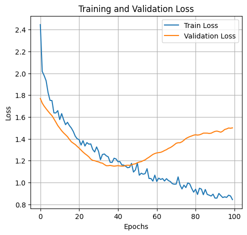

```python
history = model.fit(X_vtrain_scaled, y_vtrain_encoded, epochs=100, batch_size=128,
                    validation_data=(X_test_scaled, y_test_encoded))

# Part A - Q3 C - Plot Training Loss & Accuracy
plt.figure(figsize=(12, 5))

# Plot Training Loss and Validation Loss
plt.subplot(1, 2, 1)
plt.plot(history.history['loss'], label='Train Loss')
plt.plot(history.history['val_loss'], label='Validation Loss')
plt.xlabel('Epochs')
plt.ylabel('Loss')
plt.title('Training and Validation Loss')
plt.legend()
plt.grid()
```

### **Observation on Training and Validation Loss**

- The training loss continuously decreases, indicating the model is learning well on the training data.
- However, the validation loss starts increasing after a certain point, suggesting overfitting as the model fails to generalize to unseen data.